# R Notebook

About this file Data Fields:

- Battery: The capacity of the vehicle’s battery in kilowatt-hours (kWh).
- Car_name: The model name of the electric vehicle.
- Car_name_link: A direct link to the corresponding page on EV Database for more in-depth information.
- Efficiency: The energy efficiency rating of the vehicle in watt-hours per kilometer (Wh/km).
- Fast_charge: The fast-charging capability of the vehicle in minutes for a certain charging percentage.
- Price.DE.:The price of the electric vehicle in Germany.
- Range: The driving range of the vehicle on a single charge in kilometers.
- Top_speed:The maximum speed the vehicle can achieve in kilometers per hour.
- Acceleration..0.100.: The acceleration time from 0 to 100 kilometers per hour.

```r
library(dplyr)
library(ggplot2)
library(tidyr)
library(car)
library(MASS)
library(repr)
install.packages('pals')
library(pals)
install.packages('broom')
```

```
Error in install.packages : Updating loaded packages
```

```r
ecars_raw = read.csv('EV_cars.csv')
ecars_raw
```

| Battery | Car_name | Car_name_link | Efficiency | Fast_charge | Price.DE. | Range | Top_speed | acceleration..0.100. |
| --- | --- | --- | --- | --- | --- | --- | --- | --- |
| 75.0 | Tesla Model Y Long Range Dual Motor | https://ev-database.org/car/1619/Tesla-Model-Y-Long-Range-Dual-Motor | 172 | 670 | 59017 | 435 | 217 | 5.0 |
| 57.5 | Tesla Model 3 | https://ev-database.org/car/1991/Tesla-Model-3 | 137 | 700 | 46220 | 420 | 201 | 6.1 |
| 60.5 | BYD ATTO 3 | https://ev-database.org/car/1782/BYD-ATTO-3 | 183 | 370 | 44625 | 330 | 160 | 7.3 |
| 61.7 | MG MG4 Electric 64 kWh | https://ev-database.org/car/1708/MG-MG4-Electric-64-kWh | 171 | 630 | 39990 | 360 | 160 | 7.9 |
| 75.0 | Tesla Model 3 Long Range Dual Motor | https://ev-database.org/car/1992/Tesla-Model-3-Long-Range-Dual-Motor | 149 | 780 | 55220 | 505 | 201 | 4.4 |
| 57.5 | Tesla Model Y | https://ev-database.org/car/1743/Tesla-Model-Y | 164 | 580 | 47567 | 350 | 217 | 6.9 |
| 71.0 | BMW iX xDrive40 | https://ev-database.org/car/1472/BMW-iX-xDrive40 | 197 | 480 | 77300 | 360 | 200 | 6.1 |
| 64.0 | Volvo EX30 Single Motor ER | https://ev-database.org/car/1910/Volvo-EX30-Single-Motor-ER | 173 | 550 | 41790 | 370 | 180 | 5.3 |
| 44.0 | Citroen e-C3 | https://ev-database.org/car/2039/Citroen-e-C3 | 176 | 320 | 23300 | 250 | 135 | 11.0 |
| 82.5 | BYD SEAL 82.5 kWh AWD Excellence | https://ev-database.org/car/2002/BYD-SEAL-825-kWh-AWD-Excellence | 170 | 530 | 53668 | 485 | 180 | 3.8 |

[output cut: 350 more lines]

```r
NA
```

```r
#rename some of the columns
ecars_raw = ecars_raw %>% rename(Price = Price.DE., Acceleration = acceleration..0.100.)
```

```r
# extract the Make of each car into its own column
make = strsplit(ecars_raw$Car_name, split = ' ')

make_ = c()
n = length(make)

for (i in 1:n) {
  make_[i] = make[[i]][1]
}

ecars_raw$Make = make_
```

```r
# move columns so continuous variables are together
ecars_raw = ecars_raw %>% relocate(Make, .before = Car_name_link)
ecars_raw = ecars_raw %>% relocate(Battery, .after = Car_name_link)
ecars_raw
```

| Car_name | Make | Car_name_link | Battery | Efficiency | Fast_charge | Price | Range | Top_speed | Acceleration |
| --- | --- | --- | --- | --- | --- | --- | --- | --- | --- |
| Tesla Model Y Long Range Dual Motor | Tesla | https://ev-database.org/car/1619/Tesla-Model-Y-Long-Range-Dual-Motor | 75.0 | 172 | 670 | 59017 | 435 | 217 | 5.0 |
| Tesla Model 3 | Tesla | https://ev-database.org/car/1991/Tesla-Model-3 | 57.5 | 137 | 700 | 46220 | 420 | 201 | 6.1 |
| BYD ATTO 3 | BYD | https://ev-database.org/car/1782/BYD-ATTO-3 | 60.5 | 183 | 370 | 44625 | 330 | 160 | 7.3 |
| MG MG4 Electric 64 kWh | MG | https://ev-database.org/car/1708/MG-MG4-Electric-64-kWh | 61.7 | 171 | 630 | 39990 | 360 | 160 | 7.9 |
| Tesla Model 3 Long Range Dual Motor | Tesla | https://ev-database.org/car/1992/Tesla-Model-3-Long-Range-Dual-Motor | 75.0 | 149 | 780 | 55220 | 505 | 201 | 4.4 |
| Tesla Model Y | Tesla | https://ev-database.org/car/1743/Tesla-Model-Y | 57.5 | 164 | 580 | 47567 | 350 | 217 | 6.9 |
| BMW iX xDrive40 | BMW | https://ev-database.org/car/1472/BMW-iX-xDrive40 | 71.0 | 197 | 480 | 77300 | 360 | 200 | 6.1 |
| Volvo EX30 Single Motor ER | Volvo | https://ev-database.org/car/1910/Volvo-EX30-Single-Motor-ER | 64.0 | 173 | 550 | 41790 | 370 | 180 | 5.3 |
| Citroen e-C3 | Citroen | https://ev-database.org/car/2039/Citroen-e-C3 | 44.0 | 176 | 320 | 23300 | 250 | 135 | 11.0 |
| BYD SEAL 82.5 kWh AWD Excellence | BYD | https://ev-database.org/car/2002/BYD-SEAL-825-kWh-AWD-Excellence | 82.5 | 170 | 530 | 53668 | 485 | 180 | 3.8 |

[output cut: 350 more lines]

```r
ecars_raw = ecars_raw %>% filter(!is.na(Fast_charge))
ecars = ecars_raw %>% filter(!is.na(Price))
ecars_missing_price = ecars_raw %>% filter(is.na(Price))
```

This data required minimal processing. I created a Make variable by extracting the first word from the Car_name variable. I also renamed several columns to make them more intuitive for example acceleration..0.100. to Acceleration. I removed the two cars that did not have Fast Charge (the Renault Twingo Electric and the e.Go e.wave X) capability because this was an important feature in the linear regression and was impacting their price. Finally I made sure all the continuous variables were next to each other to simplify calling them. I split the dataframe into two. One with prices(307 objects) and one with missing prices (51 objects).

After cleaning the data 45 unique car makes were included in the ecars data used to create the linear model and 22 unique car makes were included in the data with missing prices. Additionally 14 makes that have 10 or more car models are highlighted throughout the project.

```r
length(ecars$Price)
```

```
[1] 307
```

```r
ecars$upper.limit
```

[output not shown]

[output cut: 297 more lines]

[figure not shown]

[figure not shown]

[output not shown]

[output cut: 297 more lines]

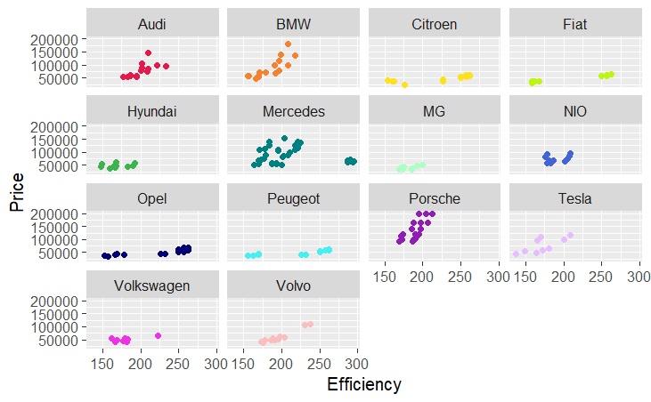

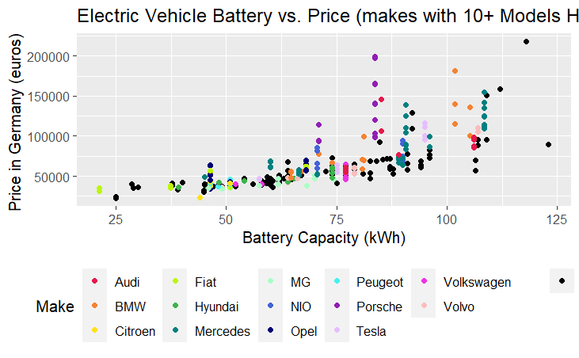

[figure not shown]

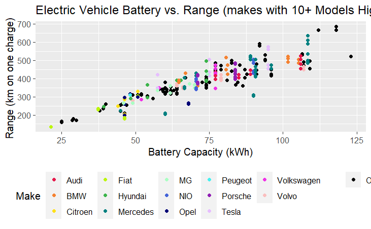

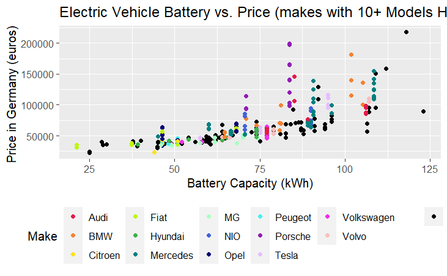